# Data Anaysis of Beetle Richness and Leaf Litter

Zachary krausman, Eryn Lackey, Riley Wares, and Afia Lockett

2026-03-24

Load in Packages

```r
#install.packages("pacman")
library(pacman)

# Load packages (emmeans used for statistical tests)
pacman::p_load(tidyverse, here, cowplot, emmeans)
```

Import datasets from the accompanying “data_wrangle_official.Rmd” file

```r
litter_averages_total <- read.csv(here("data", "processed", "litter_averages_total.csv"))
beetle_abundance_taxonID <- read.csv(here("data", "processed", "beetle_abundance_taxonID.csv"))
beetle_richness_taxonID <- read.csv(here("data", "processed", "beetle_richness_taxonID.csv"))
```

Preliminary visuals of beetle and litter observations per month.

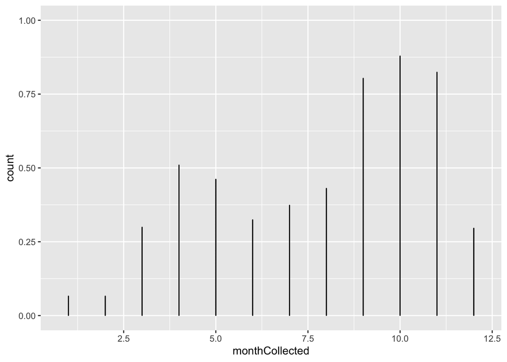

```r
ggplot(data = litter_averages_total,
       aes(x = monthCollected))+
  geom_dotplot(dotsize = 0.025)
```

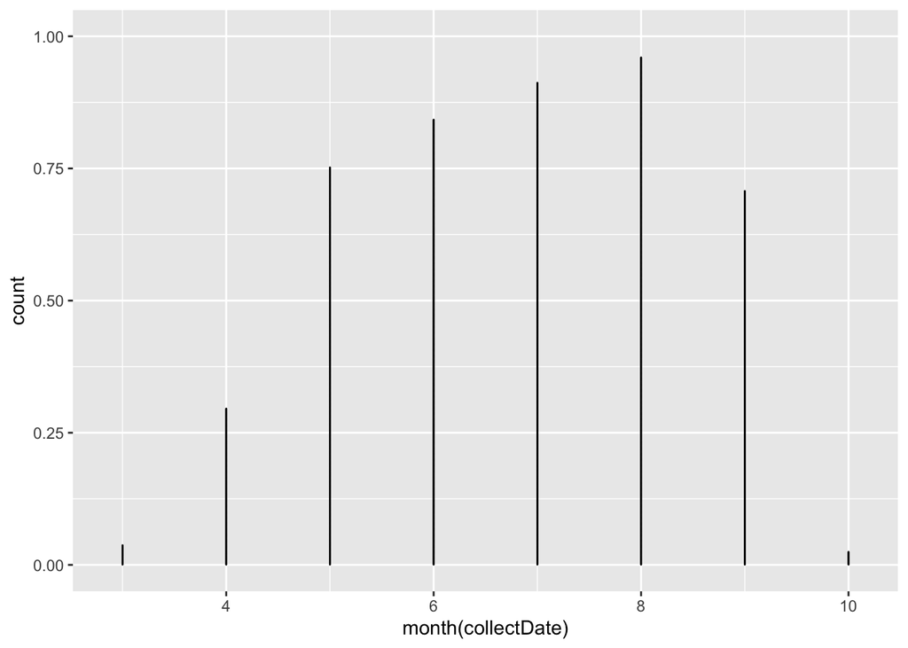

```r
ggplot(data = beetle_richness_taxonID,
       aes(x = month(collectDate)))+
  geom_dotplot(dotsize = 0.025)
```

For discussion: it would be interesting to see what is visible in the winter, but requires more data.

Create average richness with the beetle data.

```r
beetle_richness_monthly <- beetle_richness_taxonID %>%
  mutate(monthCollected = month(collectDate),
         yearCollected = year(collectDate)) %>%
  group_by(plotID, yearCollected, monthCollected) %>%
  summarize(avg_richness_monthly = mean(richness))
```

Preparing beetle and litter data for joining including creating means.

```r
beetle_richness_by_site_month <- beetle_richness_monthly %>%
  mutate(siteID = substring(plotID, 0, 4)) %>%
  group_by(siteID, yearCollected, monthCollected) %>%
  summarize(avg_richness_plotmonth = mean(avg_richness_monthly))
litter_mass_by_site_month <- litter_averages_total %>%
  mutate(siteID = substring(plotID, 0, 4)) %>%
  group_by(siteID, yearCollected, monthCollected) %>%
  summarize(avg_mass_plotmonth = mean(avgmass),
            avg_C_plotmonth = mean(avgCpercent),
            avg_N_plotmonth = mean(avgNpercent))
```

Joining litter and beetle data! Dropping Carbon and Nitrogen due to no overlap with beetle data

```r
beetle_litter_joined_table <- beetle_richness_by_site_month %>%
  full_join(litter_mass_by_site_month) %>%
  drop_na("avg_richness_plotmonth","avg_mass_plotmonth") %>%
  select(siteID, yearCollected, monthCollected, avg_richness_plotmonth, avg_mass_plotmonth)
```

Linear Model for beetle richness as a function of average leaf litter mass.

```r
beetle_litter_lm <- lm(avg_richness_plotmonth ~ (avg_mass_plotmonth), data= beetle_litter_joined_table)

summary(beetle_litter_lm)
```

```
##
## Call:
## lm(formula = avg_richness_plotmonth ~ (avg_mass_plotmonth), data = beetle_litter_joined_table)
##
## Residuals:
##     Min      1Q  Median      3Q     Max
## -1.5742 -0.7772 -0.1276  0.6700  2.7674
##
## Coefficients:
##                     Estimate Std. Error t value Pr(>|t|)
## (Intercept)         2.891186   0.106839  27.061   <2e-16 ***
## avg_mass_plotmonth -0.009981   0.010362  -0.963    0.337
## ---
## Signif. codes:  0 '***' 0.001 '**' 0.01 '*' 0.05 '.' 0.1 ' ' 1
##
## Residual standard error: 0.9675 on 137 degrees of freedom
## Multiple R-squared:  0.006727,   Adjusted R-squared:  -0.0005232
## F-statistic: 0.9278 on 1 and 137 DF,  p-value: 0.3371
```

Checking assumptions for a linear model.

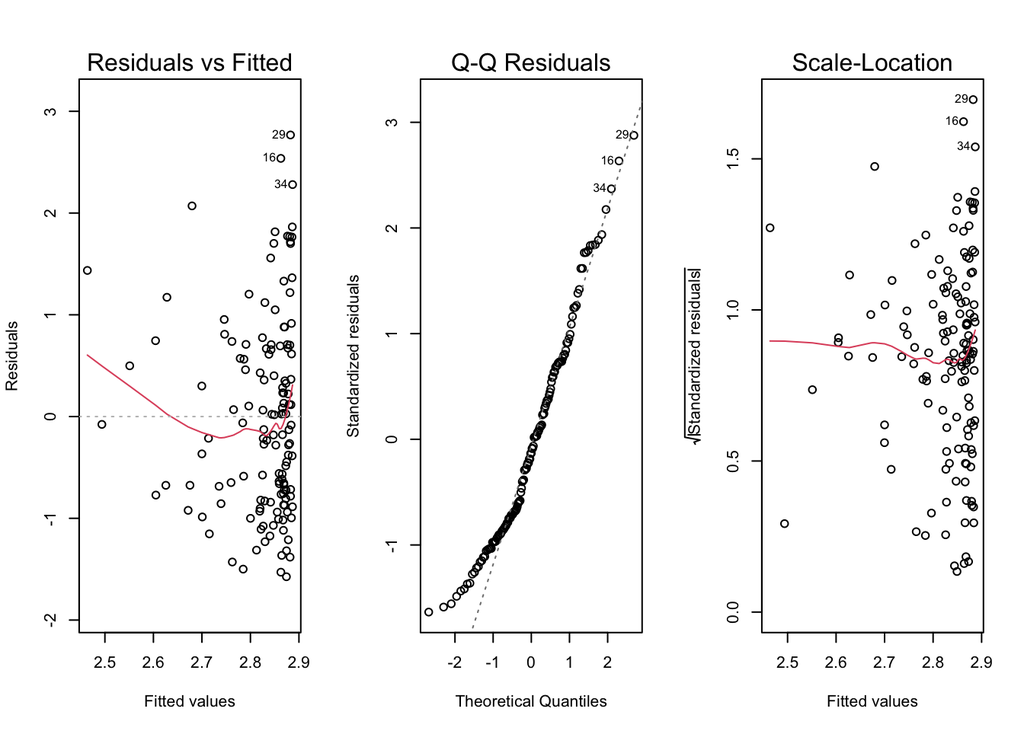

```r
par(mfrow = c(1, 3))

plot(beetle_litter_lm, which = 1:3)
```

```r
shapiro.test(beetle_litter_lm$residuals)
```

```
##
##  Shapiro-Wilk normality test
##
## data:  beetle_litter_lm$residuals
## W = 0.95803, p-value = 0.0002978
```

Average leaf litter mass per month was not a significant predictor of average beetle richness per month as seen by the linear regression model’s p-value much greater than 0.05 (F(1, 137)=.9278, p=.337). A linear regression model was used as both average leaf litter mass per month and average beetle richness per month are continuous variables. However, the linear regression model did not met the required assumptions of normality due to its low p-value of less than .05 produced by the Shapiro test and the strong concentration of points on the right side of the residuals v fitted and scale location plots. However, this lack of leaf litter mass as a predictor of beetle richness leds us to wonder whether leaf litter may still be a predictor for beetle abundance.

Average leaf litter mass per month was not a significant predictor of average beetle richness per month as seen by the p-value much greater than 0.05 **(F(1, 137) = 0.9278, p = 0.337)**.

**DO NOT INCLUDE IN POSTER** Scatterplot of beetle richness and average leaf litter mass.

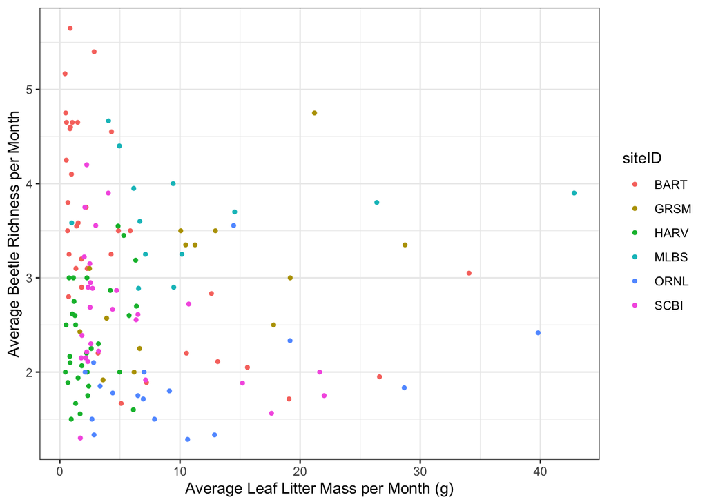

```r
ggplot(beetle_litter_joined_table,
       aes(x = avg_mass_plotmonth,
           y = avg_richness_plotmonth,
           color = siteID)) +
  labs(x = "Average Leaf Litter Mass per Month (g)",
       y = "Average Beetle Richness per Month") +
  geom_point(size = 1) +
  theme_bw()
```

```r
beetle_litter_lm_lin1 <- lm((avg_richness_plotmonth) ~ log(avg_mass_plotmonth), data= beetle_litter_joined_table)

summary(beetle_litter_lm_lin1)
```

```
##
## Call:
## lm(formula = (avg_richness_plotmonth) ~ log(avg_mass_plotmonth),
##     data = beetle_litter_joined_table)
##
## Residuals:
##     Min      1Q  Median      3Q     Max
## -1.6614 -0.7708 -0.1023  0.6919  2.5677
##
## Coefficients:
##                         Estimate Std. Error t value Pr(>|t|)
## (Intercept)              3.05600    0.12522  24.405   <2e-16 ***
## log(avg_mass_plotmonth) -0.17732    0.07362  -2.409   0.0173 *
## ---
## Signif. codes:  0 '***' 0.001 '**' 0.01 '*' 0.05 '.' 0.1 ' ' 1
##
## Residual standard error: 0.9508 on 137 degrees of freedom
## Multiple R-squared:  0.04062,    Adjusted R-squared:  0.03362
## F-statistic: 5.801 on 1 and 137 DF,  p-value: 0.01735
```

**KEEPING THIS FOR THE POSTER** Checking assumptions for log fit linear model.

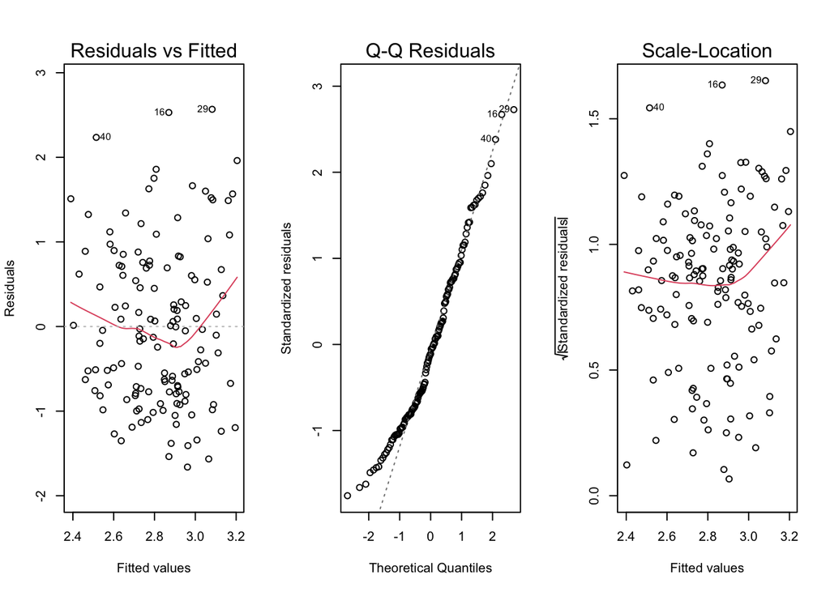

```r
par(mfrow = c(1, 3))

plot(beetle_litter_lm_lin1, which = 1:3)
```

```r
shapiro.test(beetle_litter_lm_lin1$residuals)
```

```
##
##  Shapiro-Wilk normality test
##
## data:  beetle_litter_lm_lin1$residuals
## W = 0.96414, p-value = 0.001041
```

Scatterplot of log fit beetle richness and average leaf litter mass.

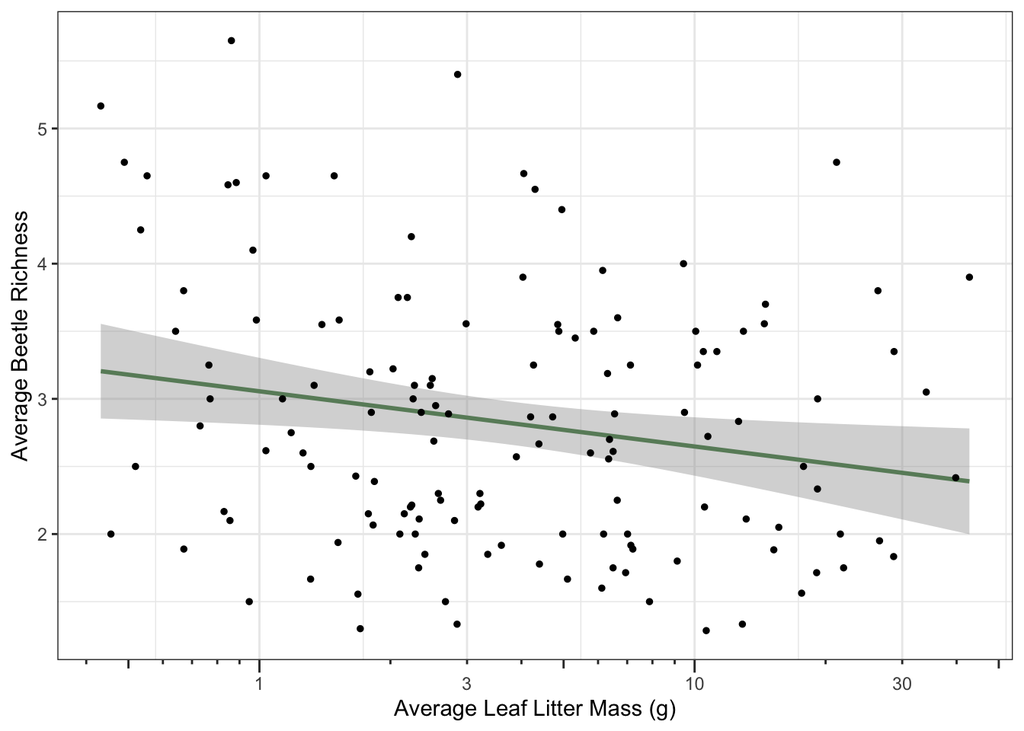

```r
ggplot(beetle_litter_joined_table,
       aes(x = avg_mass_plotmonth,
           y = avg_richness_plotmonth)) +
  labs(x = "Average Leaf Litter Mass (g)",
       y = "Average Beetle Richness") +
  geom_smooth(method = "lm",
              col = "darkseagreen4") +
  geom_point(size = 1) +
  scale_x_log10(guide = "axis_logticks") +
#  labs(col = "Site") +
  theme_bw()
```

**Figure 1.** Scatterplot showing the significant relationship between the log of the average leaf litter mass per month and average beetle richness per month. Trendline shows line of best fit globally. (F(1, 137) = 5.801, p = 0.01735). *** Exploratory anova analysis data based on site.